# hw3_markdown

Ruizhou Peng

2023-10-31

first load package we need in this assignment

```r
library(tidyverse)
library(Stat2Data)
data('Hawks')
```

### 1. Exploratory data analysis

we will use “Hawks” dataset

```r
head(Hawks)
```

```
##   Month Day Year CaptureTime ReleaseTime  BandNumber Species Age Sex Wing
## 1     9  19 1992       13:30               877-76317      RT   I      385
## 2     9  22 1992       10:30               877-76318      RT   I      376
## 3     9  23 1992       12:45               877-76319      RT   I      381
## 4     9  23 1992       10:50               745-49508      CH   I   F  265
## 5     9  27 1992       11:15              1253-98801      SS   I   F  205
## 6     9  28 1992       11:25             1207-55910       RT   I      412
##   Weight Culmen Hallux Tail StandardTail Tarsus WingPitFat KeelFat Crop
## 1    920   25.7   30.1  219           NA     NA         NA      NA   NA
## 2    930     NA     NA  221           NA     NA         NA      NA   NA
## 3    990   26.7   31.3  235           NA     NA         NA      NA   NA
## 4    470   18.7   23.5  220           NA     NA         NA      NA   NA
## 5    170   12.5   14.3  157           NA     NA         NA      NA   NA
## 6   1090   28.5   32.2  230           NA     NA         NA      NA   NA
```

#### 1.1 location estimators

q1: compute some locating estimators for Hawks’ tail

create a vector **HawksTail** from column **Tail**

```r
HawksTail <- Hawks$Tail
```

compute **mean** and **median**

```r
mean <- HawksTail%>%mean(na.rm=TRUE)
median <- HawksTail%>%median(na.rm=TRUE)
```

#### 1.2 combining location estimators with the summarize function

q1: use **summarize**,**mean**and**median**.and compute trimmed sample mean(q=0.5) of the wing length and weight

```r
Hawks%>%
  select(Wing, Weight)%>%
  summarise(across(everything(),
                   list(mean= ~mean(.x, na.rm=TRUE),
                     t_mean= ~mean(.x,trim=0.5, na.rm=TRUE),
                     med=~median(.x, na.rm=TRUE)),
                   .names= "{.col}_{.fn}"
                   )
            )
```

```
##   Wing_mean Wing_t_mean Wing_med Weight_mean Weight_t_mean Weight_med
## 1  315.6375         370      370    772.0802           970        970
```

q2: combine them with **group_by** to obtain a breakdown by species

```r
Hawks%>%
  group_by(Species)%>%
  select(Species, Wing, Weight)%>%
  summarise(across(everything(),
                   list(mean= ~mean(.x, na.rm=TRUE),
                     t_mean= ~mean(.x,trim=0.5, na.rm=TRUE),
                     med=~median(.x, na.rm=TRUE)),
                   .names= "{.col}_{.fn}"
                   )
            )
```

```
## # A tibble: 3 × 7
##   Species Wing_mean Wing_t_mean Wing_med Weight_mean Weight_t_mean Weight_med
##   <fct>       <dbl>       <dbl>    <dbl>       <dbl>         <dbl>      <dbl>
## 1 CH           244.         240      240        420.          378.       378.
## 2 RT           383.         384      384       1094.         1070       1070
## 3 SS           185.         191      191        148.          155        155
```

#### 1.3 loaction and dispersion estimators under linear transformations

q1: a variable of interest $X$ sequences has a sample mean A, define a new variable $\tilde{X}$ where $\tilde{X_i} = a X_i+b$, what is the sample mean of $\tilde{X}$ as a function of a,b and A?

ans: $Mean_{} = aA+b $

q2: let $X$ has sample variance p and standard deviation q. what is those of $\tilde{X}$?

ans: $\tilde{p} = a^2p\\ \tilde{q} = \left|a \right|q$

q3: use **HawksTail** to verify your answer, let a = 2 and b = 3

```r
X <- 2*HawksTail+3

# verify q1
A = mean(HawksTail, na.rm=TRUE)
B = mean(X, na.rm=TRUE)
2*A+3==B
```

```
## [1] TRUE
```

```r
# verify q2
P = var(HawksTail, na.rm=TRUE)
Q = sd(HawksTail, na.rm=TRUE)

P_ = var(X, na.rm=TRUE)
Q_ = sd(X, na.rm=TRUE)

(4*P == P_) & (2*Q == Q_)
```

```
## [1] TRUE
```

#### 1.4 Robustness of location estimators

now we shall investigate the robustness of several location estimators: Sample mean, sample median and trimmed mean

first extracting a vector called ‘hal’ and remove NA

```r
hal <- Hawks$Hallux
hal <- hal[!is.na(hal)]
```

then we generate outliers

```r
outlier_val <- 100
num_outliers <- 10
corrupted_hal <- c(hal, rep(outlier_val, times=num_outliers))
```

compute the means of the original and the corrupted

```r
mean(hal)
```

```
## [1] 26.41086
```

```r
mean(corrupted_hal)
```

```
## [1] 27.21776
```

then we change outliers from 0 to 1000, see what happens to the corrupted_hal

```r
nums_outlier_vec <- seq(0,1000)
means_vec <- c()

for(outlier in nums_outlier_vec){
  corrupted_hal <- c(hal,rep(outlier_val, times=outlier))
  means_vec <- c(means_vec, mean(corrupted_hal))
}
```

q1: generate sample median with corruption

```r
medians_vec <- c()

for(outlier in nums_outlier_vec){
  corrupted_hal <- c(hal,rep(outlier_val, times=outlier))
  medians_vec <- c(medians_vec, median(corrupted_hal))
}
```

q2: generate trimmed mean with corruption

```r
t_mean_vec <- c()

for(outlier in nums_outlier_vec){
  corrupted_hal <- c(hal,rep(outlier_val, times=outlier))
  t_mean_vec <- c(t_mean_vec, mean(corrupted_hal, trim=0.1))
}
```

q3: visualization

first combine these vectors into a data frame

```r
df_means_medians <- data.frame(
  num_outliers=nums_outlier_vec,
  mean=means_vec,
  t_mean=t_mean_vec,
  median=medians_vec
)
```

then reshape it to be longer, thus easy for visualization

```r
#cols is the arg for which columns to be transformed
df_means_medians_longer <- df_means_medians%>%
  pivot_longer(cols=!num_outliers,names_to = 'method', values_to = 'value')
```

now use line diagram to show trend

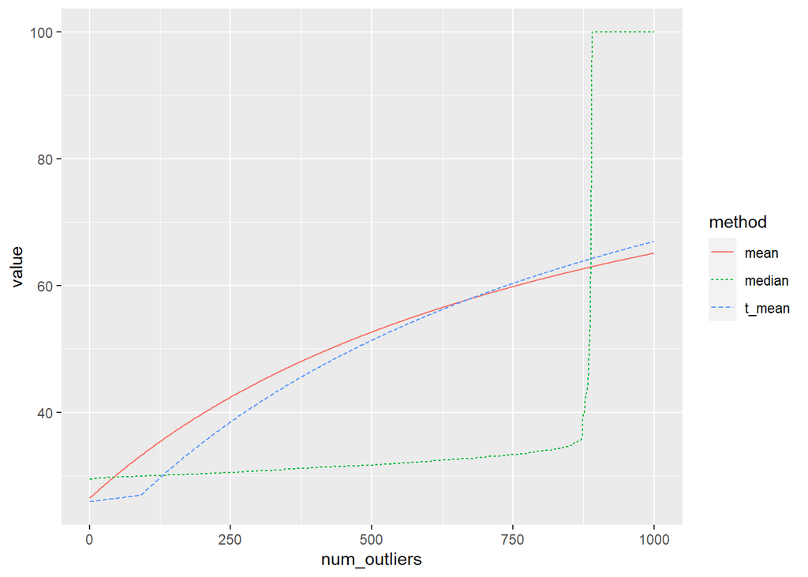

```r
df_means_medians_longer %>%ggplot(aes(x=num_outliers,
                                  y=value,
                                  color=method,
                                  linetype=method
                                  )
                                  )+geom_line()
```

#### 1.5 box plots and outliers

q1: use **ggplot** and **geom_boxplot** to create a box plot which summarizes the distribution of hawk weights broken down by species

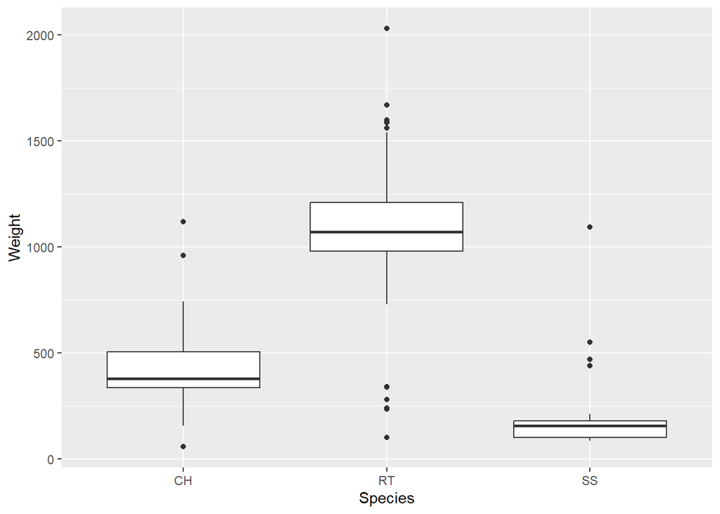

```r
Hawks%>%
  select(Species, Weight)%>%
  filter(!is.na(Weight))%>%
  group_by(Species)%>%
  ggplot(aes(x=Species,y=Weight))+geom_boxplot()
```

q2: compute 1-quartile, 2-quartile, 3-quartile of the weight grouped by species

```r
# use of summrize_at:
# vars-->variables to use in the summarize functions
# list---> list of functions to summarize

# quantile function:
# probs can be a sequence of probabilities
#but if there is only one, then don't use c() or seq() in case to make it a vector
Hawks%>%
  select(Species, Weight)%>%
  filter(!is.na(Weight))%>%
  group_by(Species)%>%
  summarise_at(vars(Weight),
               list(quantile025=~quantile(.,probs=0.25),
                    quantile050=~quantile(.,probs=0.5),
                    quantile075=~quantile(.,probs=0.75))
            )
```

```
## # A tibble: 3 × 4
##   Species quantile025 quantile050 quantile075
##   <fct>         <dbl>       <dbl>       <dbl>
## 1 CH              335        378.        505
## 2 RT              980       1070        1210
## 3 SS              100        155         178.
```

q3: create a function **num_of_outliers** which computes the number of outliers within a sample(include missing values), taking a vector as input and a number as output

```r
num_of_outliers <- function(vec){
  # first count NA numbers
  num <- sum(is.na(vec))

  # remove NA
  vec <- vec[!is.na(vec)]

  q1 <- quantile(vec, probs=0.25)
  q3 <- quantile(vec, probs=0.75)
  IQR <- q3 - q1

  upbound <- q3 + 1.5*IQR
  lowbound <- q1 - 1.5*IQR

  # add outliers
  num <- num+length(vec[vec>upbound | vec<lowbound])

  return(num)
}
```

test, and correct

```r
num_of_outliers(c(0, 40, 60, 185, NA))
```

```
## [1] 2
```

q4: count outliers of three samples of hawk weights by species

```r
Hawks%>%
  select(Species, Weight)%>%
  filter(!is.na(Weight))%>%
  group_by(Species)%>%
  summarise(num_outliers_weight=num_of_outliers(Weight))
```

```
## # A tibble: 3 × 2
##   Species num_outliers_weight
##   <fct>                 <int>
## 1 CH                        3
## 2 RT                       13
## 3 SS                        4
```

#### 1.6 covariance and correlation under linear transformation

q1: compute the covariance and correlation between Weight and Wing

```r
# cov function in R is used to calculate the cov between two vectors, not data frames?

# get two vectors
Weight <- Hawks$Weight
Wing <- Hawks$Wing

# since Weight and Wing has NA, so first replace NA
replacing_na <- function(vec){
  meanVal <- mean(vec, na.rm=TRUE)

  vec[is.na(vec)] = meanVal
  return(vec)
}


new_Weight <- replacing_na(Weight)
new_Wing <- replacing_na(Wing)

cov(new_Wing, new_Weight)
```

```
## [1] 40675.19
```

```r
cor(new_Wing, new_Weight)
```

```
## [1] 0.9290752
```

q2: suppose $X$ and $Y$ have sample covariance S and correlation R.now define $\tilde{X}=aX+b$ and $\tilde{Y}=cY+d$ what is the covariance and correlation between $\tilde{X}$ and $\tilde{Y}$?

ans: the covariance and correlation between the two new samples is$S' = ac\space S\\ R' = \frac{ac}{\left| ac \right|} R$

let a=2.4, b=7.1, c=-1, d=3,let X,Y be hawks’ weight and wing. verify the answer

```r
Weight_ <- new_Weight*2.4+7.1
Wing_ <- new_Wing*(-1)+3

# double compare can't exactly equal
cov(Weight_, Wing_)-2.4*(-1)*cov(new_Weight, new_Wing)<0.000000001
```

```
## [1] TRUE
```

```r
cor(Weight_, Wing_)-(-1)*cor(new_Weight, new_Wing)<0.0000000001
```

```
## [1] TRUE
```

### 2. random experiments, events and sample spaces, set theory

#### 2.1 random experiments, events and sample spaces

q1: write down the definition of a random experiment, event and sample space.

ans: random experiment:an experiment that can be operated many times event: a set of possible outcomes of random experiment sample space: a set of all possible outcomes of random experiment

q2: rolling a dice twice. give an example of what is an event in this random experiment. write down the sample space. what is the total number of different events in this experiment? is the empty set considered as an event?

ans:

event example–> {(1,1), (1,2)}

sample space –> {(1,1),(1,2),(1,3),(1,4),(1,5),(1,6),(2,1),(2,2),(2,3),(2,4),(2,5),(2,6),(3,1),(3,2),(3,3),(3,4),(3,5),(3,6),(4,1),(4,2),(4,3),(4,4),(4,5),(4,6),(5,1),(5,2),(5,3),(5,4),(5,5),(5,6),(6,1),(6,2),(6,3),(6,4),(6,5),(6,6)}

total number –> 2<sup>36</sup>(each element has two states: exist or not, then n elements have 2<sup>n</sup> possible outcomes)

yes, the empty set is an event

#### 2.2 set theory

q1: set operations let set A,B,C defined by A={1,2,3}, B={2,4,6}, C={4,5,6}

$$A \cup B = \{ 1,2,3,4,6 \} \\
A \cup C = \{ 1,2,3,4,5,6 \} \\
A \cap B = \{ 2 \}\\
A \cap C = \emptyset\\
A \backslash B = \{ 1,3\}\\
A \backslash C = \{ 1,2,3 \}$$
A and B are not disjoint, A and C are disjoint B and A\B are disjoint an arbitrary partition of {1,2,3,4,5,6}–>{1,2,3}and{4,5,6} {1,2,3,4,5,6}–>{1,2},{3,4},{5,6}

q2: complements, subsets and De Morgan’s law

let $\Omega$ be a sample space, take a pair of events $A \subset \Omega$ and $B \subset \Omega$

(A<sup>C</sup>)<sup>C</sup> = A

$\Omega^c = \emptyset$

since $A\subset B, so \space A^c = B\backslash A \cup B^c\\then \quad B^c \subset A^c$

$(A \cap B)^c <--> \neg (x \in A \& x \in B) == (x \notin A \| x \notin B) ==A^c \cup B^c$ $(\cap_{k=1}^KA_k)^c = \cup_{k=1}^K A_k^c$

$(A \cup B)^c <--> \neg(x\in A \| x \in B) == (x\notin A \& x\notin B) == A^c \cap B^c$ $(\cup_{k=1}^KA_k)^c = \cap_{k=1}^K A_k^c$

q3: $C^E = 2^K$

q4:

1. $\emptyset$ is disjoint from all other set $B\subset \Omega$
2. since S1,S2,S3 and S4 are pair-wise disjoint and $\cup_{i=1}^4 S_i = \cup_{i=1}^4A_i$ so S1 to S4 form a partition of A1 to A4

q5:

1. $I_{A^c} = 1-I_A$
2. B = $\Omega$
3. $(A\cap B)^c = 1- I_A·I_B$, $A^c = 1-I_A, B^c = 1-I_B$ $A^c\cup B^c = 2-I_A-I_b-(1-I_B-I_A+I_A·I_B)=1-I_A·I_B$

q6: …

### 3. visualization

in this assignment, we will explore bivariate and mutivariate plots

q1: density plot

create the density plot for three species on tail length

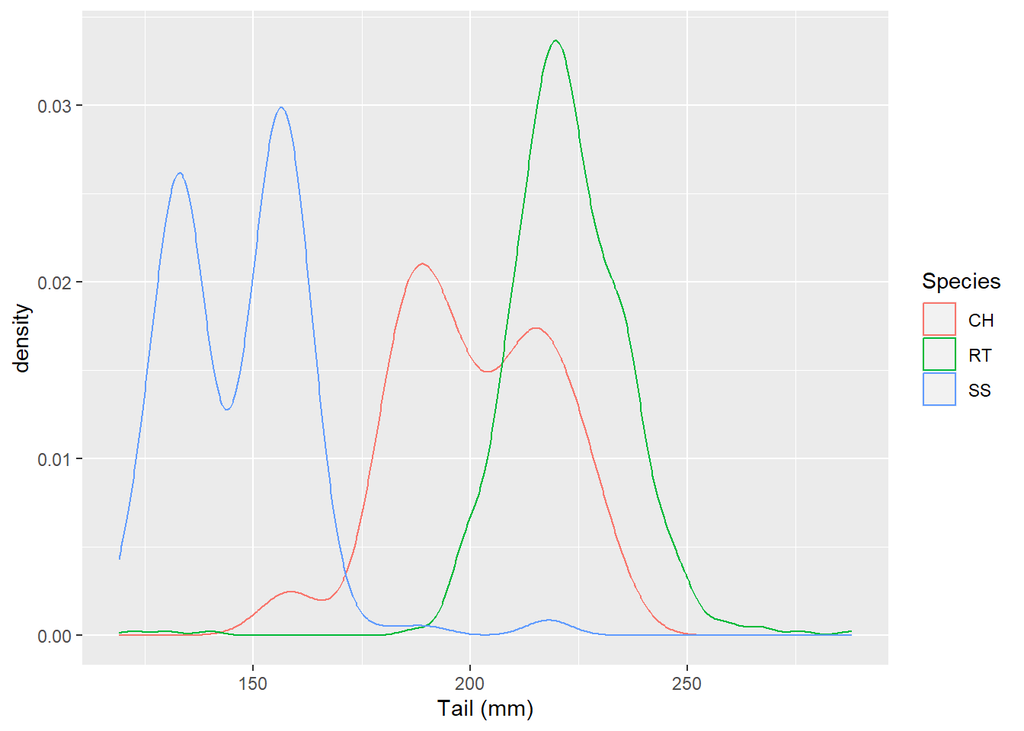

```r
Hawks%>%
  select(Species, Tail)%>%
  group_by(Species)%>%
  ggplot(aes(x=Tail, color=Species))+
  geom_density(na.rm = TRUE)+
  xlab("Tail (mm)")
```

q2:violin plot

create violin plot for three species on tail length

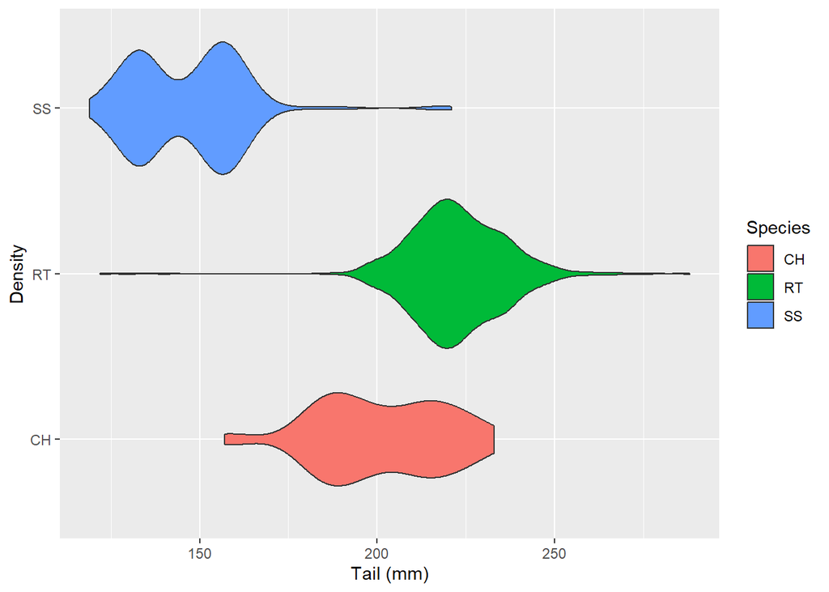

```r
# violin self-carry ydensity, so just need to appoint
# y axis to be three species and use 'fill' to colorize
Hawks%>%
  select(Species, Tail)%>%
  group_by(Species)%>%
  ggplot(aes(Tail, Species, fill=Species))+
  geom_violin(na.rm=TRUE)+
  xlab("Tail (mm)")+
  ylab("Density")
```

q3: scatter plot

create a scatter point plot of Tail and Weight in three species

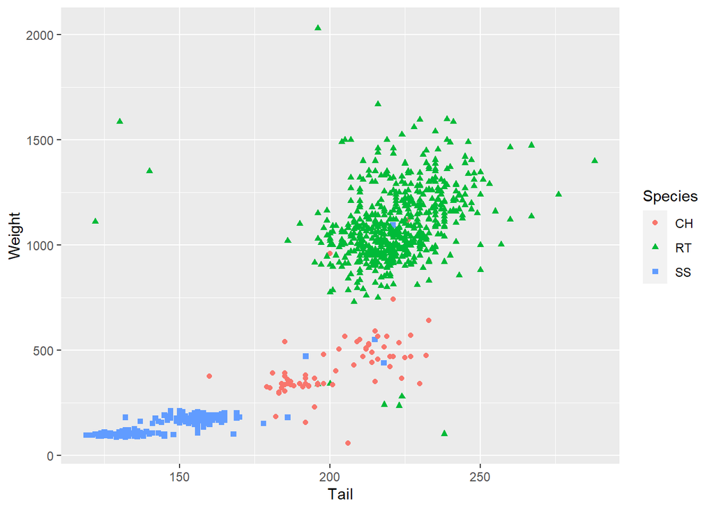

```r
Hawks%>%
  select(Species, Tail, Weight)%>%
  group_by(Species)%>%
  ggplot(aes(x=Tail, y=Weight, color=Species, shape=Species))+
  geom_point(na.rm=TRUE)
```

q4: trend line and facet wraps

create facet plot where three panels use different scales

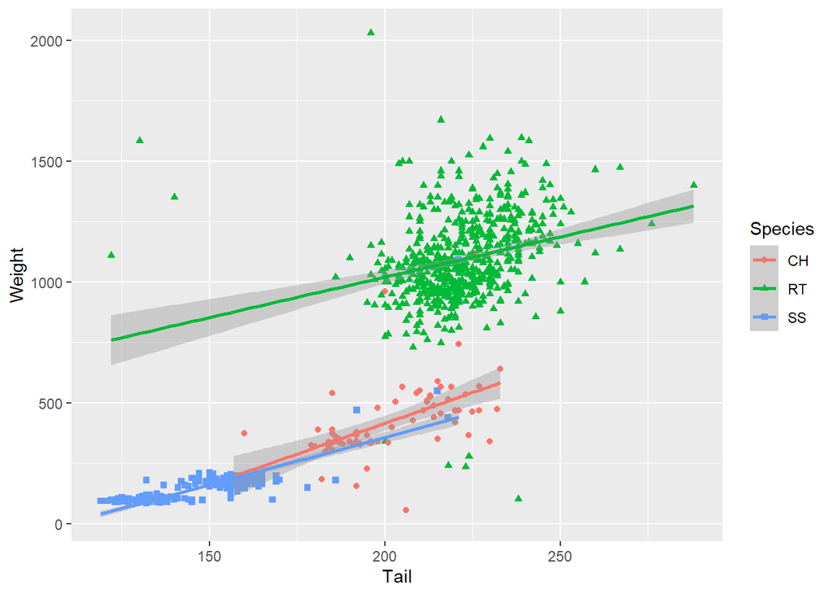

```r
# first create scatter plot with smooth trend
pt <- Hawks%>%
  select(Species, Tail, Weight)%>%
  group_by(Species)%>%
  ggplot(aes(Tail, Weight, color=Species, shape=Species))+
  geom_point(na.rm=TRUE)+
  geom_smooth(method="glm", na.rm=TRUE)

pt
```

use **facet_wrap** show respectively

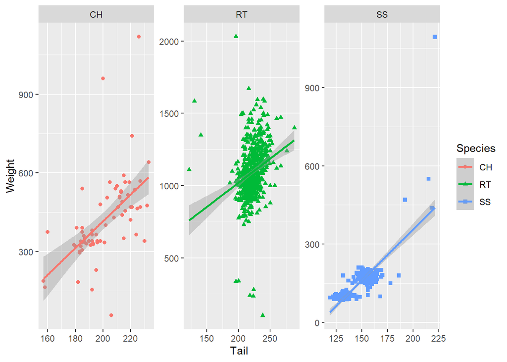

```r
# using arg 'scales' to adjust
pt + facet_wrap(vars(Species), scales='free')
```

1. this plot uses point distribution, smooth line to show trend and different color to represent different species
2. the relationship is positive, which means when tail lengths grow, the weight grows

q5: adding annotations

compute the Weight and Tail of the heaviest hawk in the dataset, then add an arrow and an annotation to indicate it

```r
# first use filter and select to get the heaviest hawk's weight and tail
heaviest_hawk <- Hawks%>%select(Weight, Tail)%>%
  filter(Weight==max(Weight, na.rm=TRUE))

heaviest_hawk
```

```
##   Weight Tail
## 1   2030  196
```

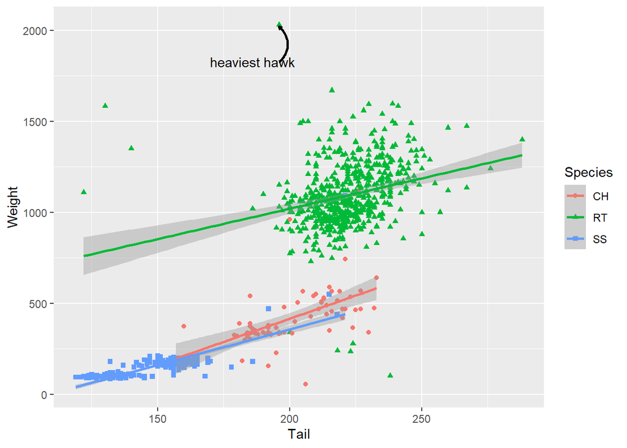

```r
# then add annotation, use annoation to add text
# and geom_curve to draw arrow between (x,y) and (xend,yend)
X=heaviest_hawk$Tail
Y=heaviest_hawk$Weight

pt +
  geom_curve(aes(x=X,y=Y*0.9, xend=X, yend=Y-10), color="black", linewidth=1, arrow=arrow(length = unit(0.1, "cm")))+
  annotate("text",x=X-10, y=0.9*Y, label="heaviest hawk")
```